# Untitled

Unnamed

2020 10 21

첫번째 - 외식업의 현황을 확인하기 위해 시계열 그래프를 생성함 - 업종 내의 항목을 표현하기 위해 groupby 설정 - 시계열 그래프의 가독성을 높이기 위해 중앙선을 추가

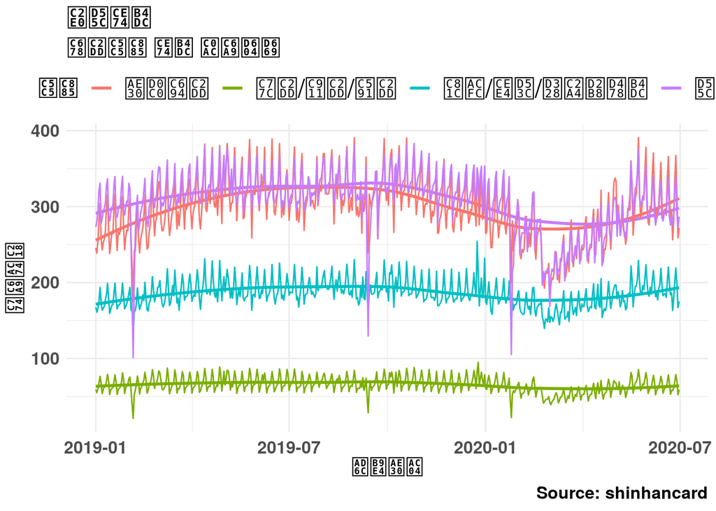

```r
shinhancard %>%
  rename(date = "일별") %>%
  group_by(date, 업종) %>%
  summarise(mean = mean(`카드이용건수(천건)`)) %>%
  filter(data <- 업종 =="한식"| 업종 =="일식/중식/양식"|
           업종 =="제과/커피/패스트푸드"| 업종 =="기타요식") %>%
  ggplot(aes(x=date)) +
  geom_smooth(aes(y=mean, colour = 업종), se= F) +
  geom_line(aes(y=mean, colour = 업종)) +
  theme_minimal() +
  theme(axis.text.x = element_text(vjust=0.6, size = 12, face = "bold"),
        axis.text.y = element_text(size =12, face = 'bold'),
        axis.title=element_text(size=14, face='bold'),
        title = element_text(size=15, face='bold'),
        legend.position = "top",
        legend.text = element_text(size= 18))+
  labs(title="신한카드",
       subtitle="외식업종 카드 사용현황",
       caption="Source: shinhancard",
       y="이용건수", x= "구매기간")
```

두번째 - 업종별 카드사용 현황을 세부적으로 확인 하기위해 바형 그래프로 설정함

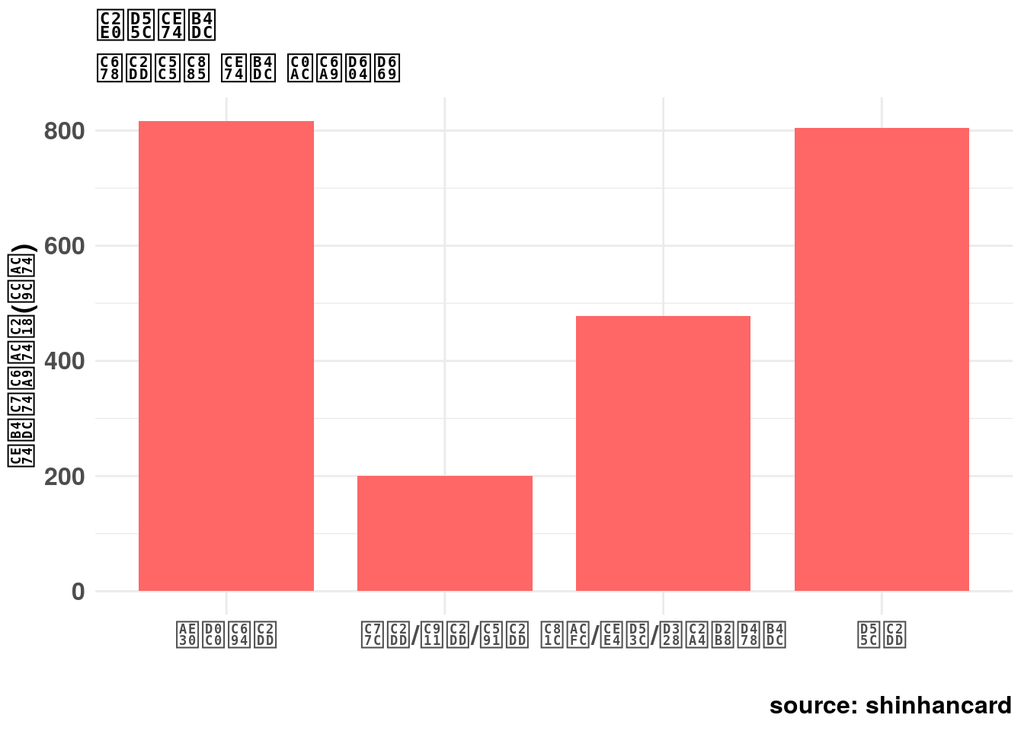

```r
shinhancard %>%
  group_by(업종, 일별) %>%
  count(`카드이용건수(천건)`) %>%
  filter(data <- 업종 =="한식"| 업종 =="일식/중식/양식"|
           업종 =="제과/커피/패스트푸드"| 업종 =="기타요식") %>%
  ggplot(aes(x = 업종, y= `카드이용건수(천건)`)) +
  geom_bar(stat = "identity", position= 'dodge', width=.8, fill= "#FF6666") +
  theme_minimal() +
  theme(axis.text.x = element_text(size = 14, face = "bold"),
        axis.text.y = element_text(size =12, face = 'bold'),
        axis.title=element_text(size=14, face='bold'),
        title = element_text(size=15, face='bold'),
        legend.position = "top") +
  labs(title="신한카드",
       subtitle="외식업종 카드 사용현황",
       caption="source: shinhancard",
       x= " ")
```

세번째 - 외식업의 현황을 좀더 자세하게 확인하기 위하여 연령대별로 기간그래프를 생성함? - 평소에는 20대의 매출이 많았으나 코로나 대책인 거리두기의 일환으로 20대의 매출이 크게 감소한 것으로 생각됨

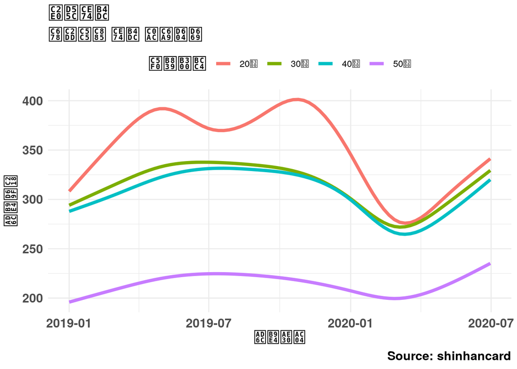

```r
shinhancard %>%
  rename(date = "일별") %>%
  group_by(date, 업종, 연령대별) %>%
  filter(연령대별 %in% c("20대", "30대", "40대", "50대")) %>%
  summarise(mean = mean(`카드이용건수(천건)`)) %>%
  filter(data <- 업종 =="한식"| 업종 =="일식/중식/양식"|
           업종 =="제과/커피/패스트푸드"| 업종 =="기타요식") %>%
  ggplot(aes(x=date)) +
  geom_smooth(aes(y=mean, colour = 연령대별),se=F, size=1.5) +
  labs(title="신한카드",
       subtitle="외식업종 카드 사용현황",
       caption="Source: shinhancard",
       y="구매횟수", x= "구매기간") +
  theme_minimal() +
  theme(axis.text.x = element_text(vjust=0.6, size = 12, face = "bold"),
        axis.text.y = element_text(size =12, face = 'bold'),
        axis.title=element_text(size=14, face='bold'),
        title = element_text(size=15, face='bold'),
        legend.position = "top")
```

네번째 - 연령대별 지출항목을 좀더 명확히 확인하기 위해 연령대별로 업종을 나눔 - 20, 30대의 매출이 가장 높은 업종은 기타요식(유흥음식/주점, 나이트클럽)으로 확인되고 40,50대의 경우 한식의 비중이 가장 높은 것을 확인됨

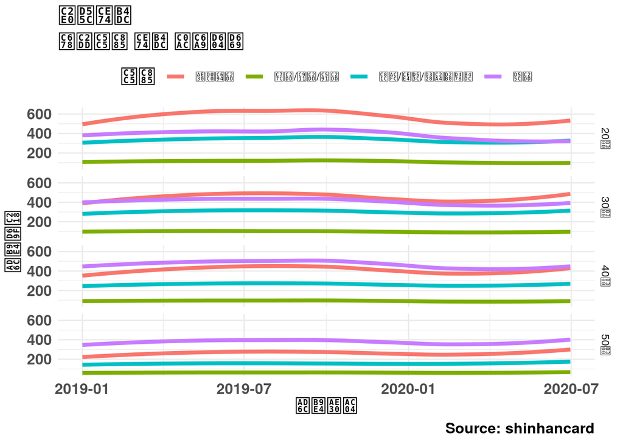

```r
shinhancard %>%
  rename(date = "일별") %>%
  group_by(date, 업종, 연령대별) %>%
  filter(연령대별 %in% c("20대", "30대", "40대", "50대")) %>%
  summarise(mean = mean(`카드이용건수(천건)`)) %>%
  filter(data <- 업종 =="한식"| 업종 =="일식/중식/양식"|
           업종 =="제과/커피/패스트푸드"| 업종 =="기타요식") %>%
  ggplot(aes(x=date)) +
  geom_smooth(aes(y=mean, colour = 업종),se=F, size=1.5) +
  facet_grid(연령대별 ~ .) +
  labs(title="신한카드",
       subtitle="외식업종 카드 사용현황",
       caption="Source: shinhancard",
       y="구매횟수", x= "구매기간") +
  theme_minimal() +
  theme(axis.text.x = element_text(vjust=0.6, size = 12, face = "bold"),
        axis.text.y = element_text(size =12, face = 'bold'),
        axis.title=element_text(size=14, face='bold'),
        title = element_text(size=15, face='bold'),
        legend.position = "top")
```

다섯번째 - 시계열그래프, 기간그래프를 확인한 결과 코로나 시기에 맞물려 감소하다 다시 증가하는 추세를 보여, 증감이 모두 코로나로 인해 발생한 것인지 확인하기 위해 전년동월 데이터를 활용하기로 함 - 전년도, 금년도 데이터를 비교한 결과 전년대비 업종별 매출이 모두 감소한 것을 확인하여 코로나로 인해 매출이 감소한 것으로 추정함 - 전년도 데이터를 비교하기 위해 mutate를 사용하여 코로나 함수를 설정함

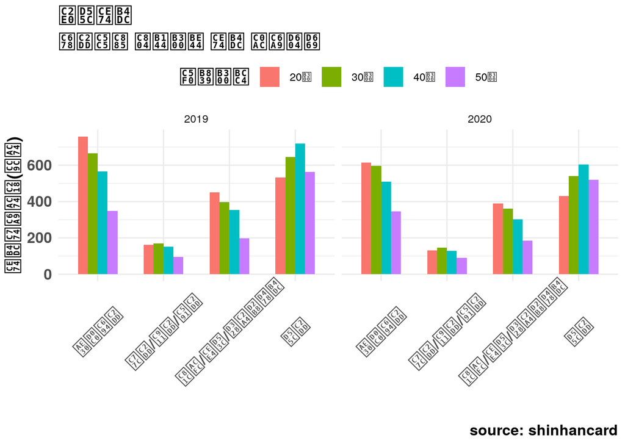

```r
shinhan_covid %>%
  group_by(일별, 업종, 연령대별, 코로나) %>%
  summarise(업종, `카드이용건수(천건)`) %>%
  filter(연령대별 %in% c("20대", "30대", "40대", "50대")) %>%
  filter(data <- 업종 =="한식"| 업종 =="일식/중식/양식"|
           업종 =="제과/커피/패스트푸드"| 업종 =="기타요식") %>%
  ggplot(aes(x = 업종, y= `카드이용건수(천건)`, fill= 연령대별)) +
  geom_bar(stat = "identity", position = 'dodge', width=.6) +
  facet_grid(. ~코로나) +
  labs(title="신한카드",
       subtitle="외식업종 전년대비 카드 사용현황",
       caption="source: shinhancard",
       x= " ") +
  theme_minimal() +
  theme(axis.text.x = element_text(angle=45, vjust=0.6, size = 12, face = "bold"),
        axis.text.y = element_text(size =12, face = 'bold'),
        axis.title=element_text(size=14, face='bold'),
        title = element_text(size=15, face='bold'),
        legend.position = "top")
```